# TIDYVERSE VIGNETTE

Keeno Glanville

2022-11-09

```r
library(tidyverse)
```

```r
library(ggplot2)
```

# Tidyverse Vignette

## Load kaggle set Data

Github:https://raw.githubusercontent.com/kglan/FALL2022TIDYVERSE/main/UCI_Credit_Card.csv kaggle: https://www.kaggle.com/datasets/uciml/default-of-credit-card-clients-dataset

## Information on the Dataset

- SEX: Gender (1=male, 2=female)
- EDUCATION: (1=graduate school, 2=university, 3=high school, 4=others, 5=unknown, 6=unknown)
- MARRIAGE: Marital status (1=married, 2=single, 3=others)
- AGE: Age in years

```r
ccd <- read.csv("https://raw.githubusercontent.com/kglan/FALL2022TIDYVERSE/main/UCI_Credit_Card.csv")
names(ccd)
```

```
##  [1] "ID"                         "LIMIT_BAL"
##  [3] "SEX"                        "EDUCATION"
##  [5] "MARRIAGE"                   "AGE"
##  [7] "PAY_0"                      "PAY_2"
##  [9] "PAY_3"                      "PAY_4"
## [11] "PAY_5"                      "PAY_6"
## [13] "BILL_AMT1"                  "BILL_AMT2"
## [15] "BILL_AMT3"                  "BILL_AMT4"
## [17] "BILL_AMT5"                  "BILL_AMT6"
## [19] "PAY_AMT1"                   "PAY_AMT2"
## [21] "PAY_AMT3"                   "PAY_AMT4"
## [23] "PAY_AMT5"                   "PAY_AMT6"
## [25] "default.payment.next.month"
```

## Research question

**What are the strongest contributing factors(nominal) towards client defaulting on their payments? Are there any trends?**

## Cases

**Each case represents individuals with credit card debt and their current status with defaulting on their payment. There are *30,000* observations**

```r
dim(ccd)
```

```
## [1] 30000    25
```

```r
head(ccd)
```

```
##   ID LIMIT_BAL SEX EDUCATION MARRIAGE AGE PAY_0 PAY_2 PAY_3 PAY_4 PAY_5 PAY_6
## 1  1     20000   2         2        1  24     2     2    -1    -1    -2    -2
## 2  2    120000   2         2        2  26    -1     2     0     0     0     2
## 3  3     90000   2         2        2  34     0     0     0     0     0     0
## 4  4     50000   2         2        1  37     0     0     0     0     0     0
## 5  5     50000   1         2        1  57    -1     0    -1     0     0     0
## 6  6     50000   1         1        2  37     0     0     0     0     0     0
##   BILL_AMT1 BILL_AMT2 BILL_AMT3 BILL_AMT4 BILL_AMT5 BILL_AMT6 PAY_AMT1 PAY_AMT2
## 1      3913      3102       689         0         0         0        0      689
## 2      2682      1725      2682      3272      3455      3261        0     1000
## 3     29239     14027     13559     14331     14948     15549     1518     1500
## 4     46990     48233     49291     28314     28959     29547     2000     2019
## 5      8617      5670     35835     20940     19146     19131     2000    36681
## 6     64400     57069     57608     19394     19619     20024     2500     1815
##   PAY_AMT3 PAY_AMT4 PAY_AMT5 PAY_AMT6 default.payment.next.month
## 1        0        0        0        0                          1
## 2     1000     1000        0     2000                          1
## 3     1000     1000     1000     5000                          0
## 4     1200     1100     1069     1000                          0
## 5    10000     9000      689      679                          0
## 6      657     1000     1000      800                          0
```

```r
ccd_n <- ccd%>%
  select(1,3,4,5,6,25)
head(ccd_n)
```

```
##   ID SEX EDUCATION MARRIAGE AGE default.payment.next.month
## 1  1   2         2        1  24                          1
## 2  2   2         2        2  26                          1
## 3  3   2         2        2  34                          0
## 4  4   2         2        1  37                          0
## 5  5   1         2        1  57                          0
## 6  6   1         1        2  37                          0
```

```r
ccd1<- ccd_n%>%
  filter(default.payment.next.month == 1)
ccd0<- ccd_n%>%
  filter(default.payment.next.month == 1)
```

## Analysis

** How can we better understand this dataset and its correlations with nominal features?

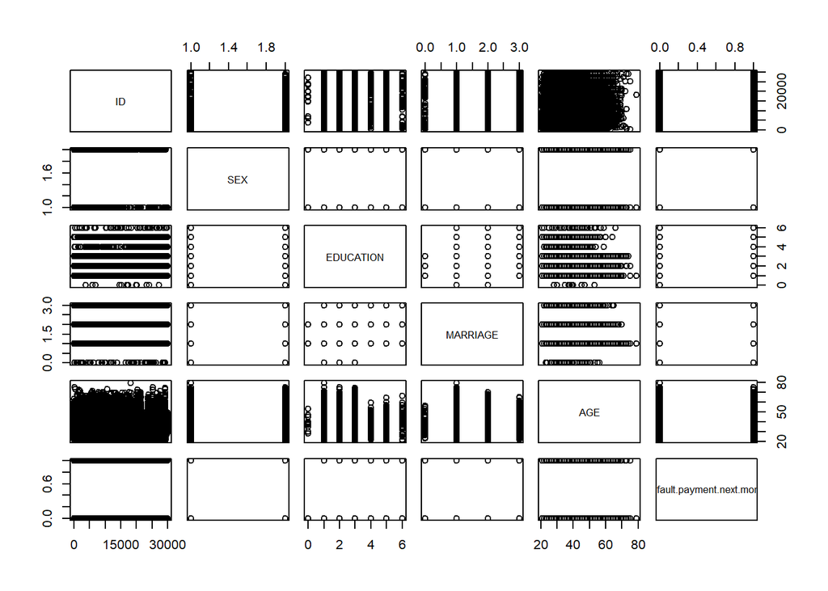

```r
pairs(data = ccd, ~ ID + SEX + EDUCATION+ MARRIAGE + AGE+ default.payment.next.month)
```

## We now want to see how the Data correlates with default in the next month payment

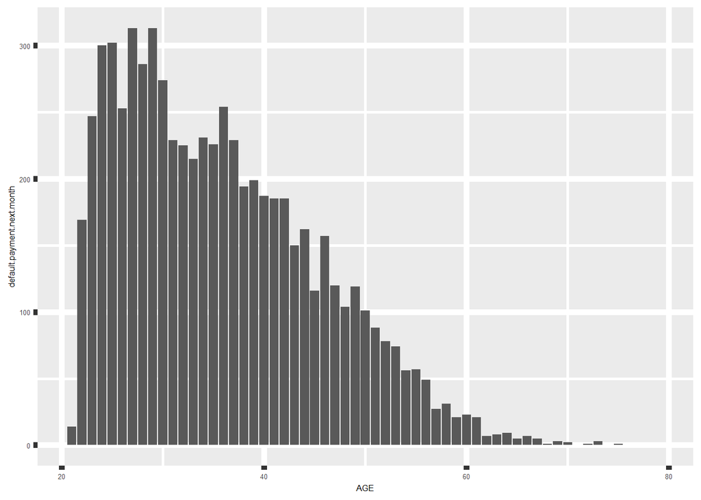

```r
ggplot(ccd_n, aes(x = AGE, y = default.payment.next.month)) +
  geom_bar(stat = "identity") +
  theme(text = element_text(size = 6),element_line(size = 2))
```

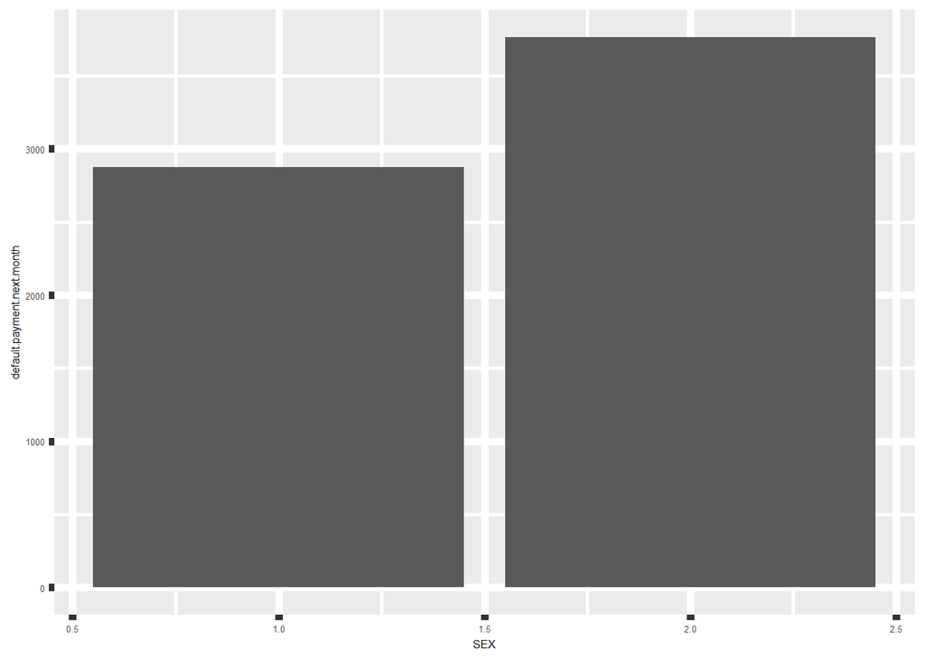

```r
ggplot(ccd_n, aes(x = SEX, y = default.payment.next.month)) +
  geom_bar(stat = "identity") +
  theme(text = element_text(size = 6),element_line(size = 2))
```

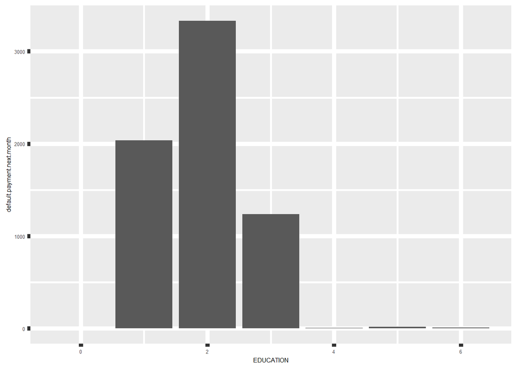

```r
ggplot(ccd_n, aes(x = EDUCATION, y = default.payment.next.month)) +
  geom_bar(stat = "identity") +
  theme(text = element_text(size = 6),element_line(size = 2))
```

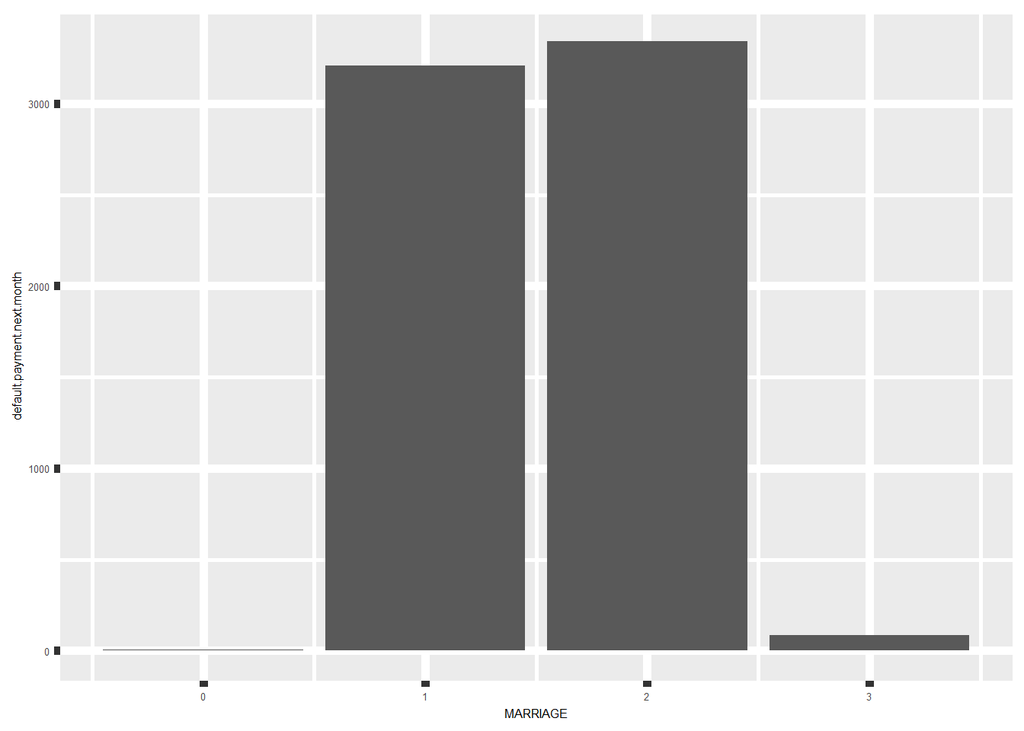

```r
ggplot(ccd_n, aes(x = MARRIAGE, y = default.payment.next.month)) +
  geom_bar(stat = "identity") +
  theme(text = element_text(size = 6),element_line(size = 2))
```

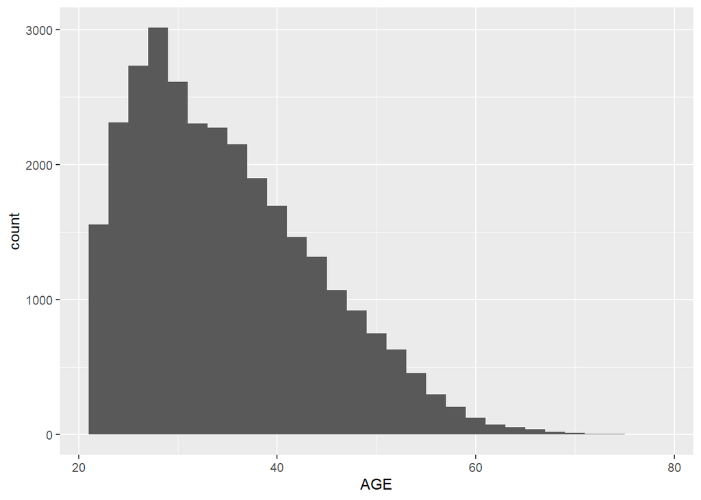

```r
ggplot(ccd_n, aes(x = AGE))+
  geom_histogram()
```

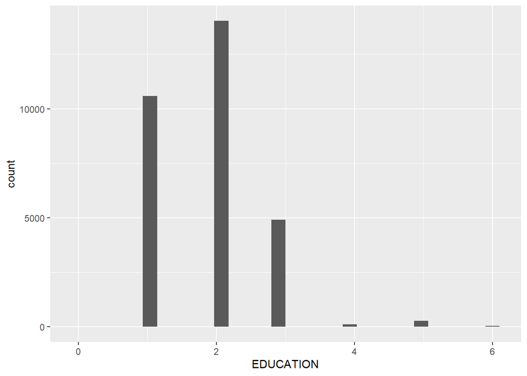

```r
ggplot(ccd_n, aes(x = EDUCATION))+
  geom_histogram()
```

## We Notice these factors have high instances of bankruptcy:

- age ranges between 20-30 are more likely to default on their next payment.
- Individuals who went to university are most likely to default (followed by graduates)
- Females are more at fault
- With married and single individuals not having too much difference

## Conclusion:

Utilizing the ggplot2 function we were able to determine that the most at risk for defaults on their next credit card payments could be women between the ages of 20-30 and have been through higher education.